# Supplementary: FLK Analysis

Steve Pederson

10 June, 2019

```r
library(SeqArray)
library(tidyverse)
library(magrittr)
library(rtracklayer)
library(GenomicRanges)
library(parallel)
library(reshape2)
library(pander)
library(scales)
library(stringr)
library(qqman)
library(plyranges)
library(ape)
theme_set(theme_bw())
```

```r
nCores <- min(12, detectCores() - 1)
```

## Introduction

This supplementary analysis uses the FLK model as outlined in [Bonhomme et al, Detecting Selection in Population Trees: The Lewontin and Krakauer Test Extended](https://dx.doi.org/10.1534%2Fgenetics.110.117275). This test is robust to genetic drift, and is able to detect signatures of selection. However as this is a linear evolution dataset within one population as opposed to a series of approximately parallel selection events occurring within a series of populations, the assumptions of the FLK model may be less than satisfied. Hence this is presented as supplementary information.

The script `FLK.R` was obtained from the [QGSP](https://qgsp.jouy.inra.fr/archives/FLK/FLK.R) and loaded into `R`

```r
source("FLK.R")
```

A third population was included as an outlier group, representing a population separated by a large geographic distance. 35 samples were taken from [Schwensow et al](http://onlinelibrary.wiley.com/doi/10.1111/mec.14228/full).

## Setup

### Genes

```r
ensGenes <- file.path("..", "external", "Oryctolagus_cuniculus.OryCun2.0.96.gff3.gz") %>%
    import.gff3(feature.type = "gene", sequenceRegionsAsSeqinfo = TRUE)
```

### SNP Data Loading

The same VCF/GDS data as in 03_snpFiltering was loaded, retaining data from the third population (Turretfield). A `GRanges` object was defined containing all SNP information, and incorporating the Locus and Col information to remain compatible with `stacks`.

```r
gdsPath <- file.path("..", "5_stacks", "gds", "populations.snps.gds")
gdsFile <- seqOpen(gdsPath, readonly = TRUE)
```

```r
allSnpsGR <- tibble(
    variant.id = seqGetData(gdsFile, "variant.id"),
    position = seqGetData(gdsFile, "position"),
    chromosome = seqGetData(gdsFile, "chromosome"),
    id = seqGetData(gdsFile, "annotation/id")
) %>%
    mutate(id = str_remove(id, ":[\\+\\-]$")) %>%
    separate(id, into = c("Locus ID", "Col")) %>%
    mutate(Col = as.integer(Col) - 1,
           snpID = paste(`Locus ID`, Col, sep = "_")) %>%
    makeGRangesFromDataFrame(
        seqinfo = seqinfo(ensGenes),
        keep.extra.columns = TRUE,
        ignore.strand = TRUE,
        seqnames.field = "chromosome",
        start.field = "position",
        end.field = "position")
```

```r
sampleID <- tibble(
    Sample = seqGetData(gdsFile, "sample.annotation/Sample"),
    Population = seqGetData(gdsFile, "sample.annotation/Population"),
    Location = seqGetData(gdsFile, "sample.annotation/Location")
)
popSizes <- sampleID %>%
    group_by(Population) %>%
    summarise(n = dplyr::n())
```

```r
snps2Keep <- readRDS("keepSNPsAfterLDPruning.RDS") %>%
    filter(!variant.id %in% readRDS("regionSNPs.RDS"))
```

```r
genotypes <- tibble(
    variant.id = seqGetData(gdsFile, "variant.id")
) %>%
    cbind(seqGetData(gdsFile, "genotype") %>%
              apply(MARGIN = 3, colSums) %>%
              t %>%
              set_colnames(sampleID$Sample)) %>%
    as_tibble() %>%
    gather(Sample, Genotype, -variant.id) %>%
    dplyr::filter(!is.na(Genotype)) %>%
    arrange(variant.id, Sample) %>%
    left_join(sampleID)
snpIn1996 <- genotypes %>%
    filter(Population == 1996) %>%
    group_by(variant.id) %>%
    summarise(maf = mean(Genotype) / 2) %>%
    filter(maf > 0) %>%
    dplyr::select(variant.id)
genotypes %<>%
    right_join(snpIn1996)
```

```r
seqClose(gdsFile)
```

## FLK

### Define Neutral Loci

```r
neutralGR <- allSnpsGR %>%
    resize(199999, fix = "center") %>%
    trim() %>%
    filter_by_non_overlaps(ensGenes)
```

```r
neutMatrix <- genotypes %>%
    filter(variant.id %in% neutralGR$variant.id) %>%
    group_by(variant.id, Population) %>%
    summarise(maf = mean(Genotype) / 2,
              n = dplyr::n()) %>%
    left_join(popSizes, by = "Population") %>%
    mutate(p = n.x / n.y,
           nPops = dplyr::n()) %>%
    filter(min(p) > 0.95, nPops == 3) %>%
    ungroup() %>%
    dplyr::select(variant.id, Population, maf) %>%
    spread(Population, maf) %>%
    left_join(allSnpsGR %>%
                  mcols() %>%
                  as.data.frame()) %>%
    distinct(Locus.ID, `1996`, `2010`, `2012`) %>%
    as.data.frame() %>%
    dplyr::select(-Locus.ID) %>%
    t() %>%
    set_rownames(c("1996", "Outgroup (Turretfield)", "2012"))
```

- Putative neutral loci were defined as those > 100kb from a gene, with the additional criteria that the SNP be identified in >95% of individuals from all 3 populations.
- Where multiple SNPs were detected within a locus with identical frequencies, only one was included.
- Reynolds distance was calculated using the minor allele frequencies for this set of loci.

### Estimation of the Co-ancestry Matrix (F_ij)

The above gave a final list of 3,179 putatively neutral SNPs for estimation of Reynolds Distance as the first step towards calculating the co-ancestry matrix $\mathcal{F}_{ij}$.

```r
reynDist <- reynolds(neutMatrix)
```

Reynolds Distance as calculated using the neutral loci as defined above.

|  | 1996 | Outgroup (Turretfield) | 2012 |
| --- | --- | --- | --- |
| **1996** | 0 | 0.1117 | 0.01349 |
| **Outgroup (Turretfield)** | 0.1117 | 0 | 0.1172 |
| **2012** | 0.01349 | 0.1172 | 0 |

```r
F_ij <- Fij(neutMatrix, "Outgroup (Turretfield)", reynDist)
```

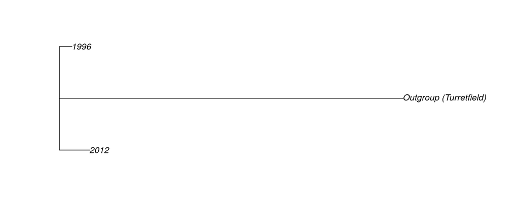

*Neighbour-joining Tree for all 3 populations.*

### FLK Results

```r
flkResults <- genotypes %>%
    filter(variant.id %in% snps2Keep$variant.id,
           Population != 2010) %>%
    group_by(variant.id, Population) %>%
    summarise(maf = mean(Genotype) / 2) %>%
    spread(Population, maf) %>%
    as.data.frame() %>%
    column_to_rownames("variant.id") %>%
    t() %>%
    FLK(Fij = F_ij) %>%
    rownames_to_column("variant.id") %>%
    as_tibble() %>%
    dplyr::select(variant.id, Ht, contains("F.LK")) %>%
    mutate(FDR = p.adjust(F.LK.p.val, method = "fdr"),
           P_bonf = p.adjust(F.LK.p.val, method = "bonferroni")) %>%
    arrange(F.LK.p.val)
```

Potentially significant SNPs under FLK, showing MAFs for both time-points

| variant.id | snpID | Location | 1996 | 2012 | p | FDR |
| --- | --- | --- | --- | --- | --- | --- |
| 81518 | 2689075_49 | 16:56,527,308 | 0.05814 | 0.3043 | 8.931e-06 | 0.08919 |
| 133433 | 4044777_119 | GL018933:204,058 | 0.01754 | 0.2019 | 1.399e-05 | 0.08919 |
| 60986 | 1997286_93 | 12:141,844,290 | 0.08889 | 0.3556 | 1.417e-05 | 0.08919 |
| 91957 | 3000704_65 | 19:13,055,154 | 0.03191 | 0.234 | 2e-05 | 0.09438 |
| 74214 | 2405359_66 | 14:97,813,263 | 0.02083 | 0.2021 | 2.586e-05 | 0.09763 |

- No SNPs achieved statistical significance under FLK using Bonferroni’s adjustment
- A total of 5 were considered of potential interest using an FDR of 0.1.

Genes within 40kb of SNPs considered as being of interest under FLK to an FDR of 10%

| variant.id | snpID | gene | Location | F.LK.p.val | FDR |
| --- | --- | --- | --- | --- | --- |
| 60986 | 1997286_93 | ESR1 | 12:141,844,290 | 1.417e-05 | 0.08919 |
| 74214 | 2405359_66 | STXBP5L | 14:97,813,263 | 2.586e-05 | 0.09763 |
| 81518 | 2689075_49 | ESRRG | 16:56,527,308 | 8.931e-06 | 0.08919 |
| 133433 | 4044777_119 | FNBP1 | GL018933:204,058 | 1.399e-05 | 0.08919 |

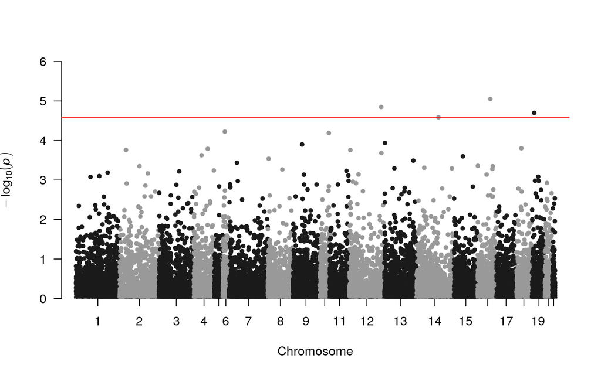

*Manhattan plot showing results for all SNPs on chromosomes 1:21 when analysing using the FLK model. The horizontal line indicates the cutoff for an FDR of 10%. No SNPs were considered significant under the Bonferroni adjustment.*

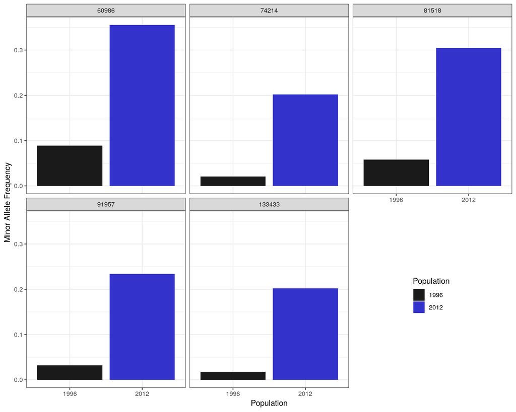

*Minor Allele Frequencies for the SNPs identified under FLK to an FDR of 10%*

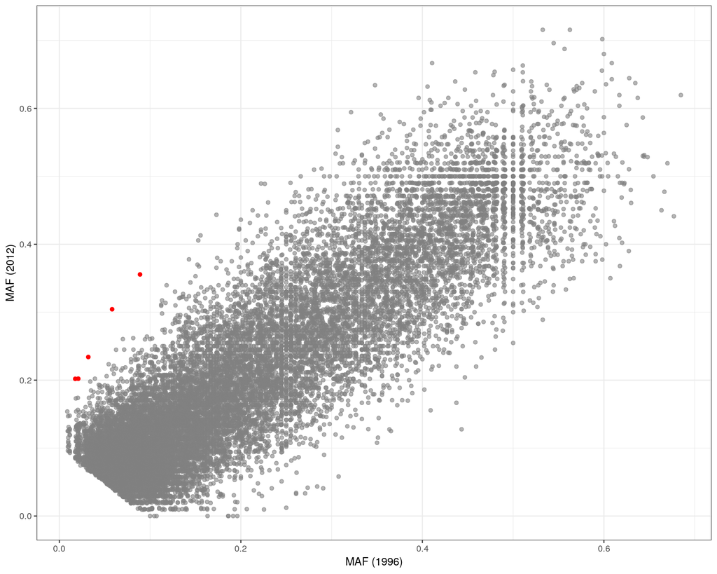

*MAFS from all tested SNPs, showing those considered as significant under FLK in red.*

```r
flkResults %>% write_tsv("flkResults.tsv")
```

## Session Info

**R version 3.6.0 (2019-04-26)**

**Platform:** x86_64-pc-linux-gnu (64-bit)

**locale:** *LC_CTYPE=en_AU.UTF-8*, *LC_NUMERIC=C*, *LC_TIME=en_AU.UTF-8*, *LC_COLLATE=en_AU.UTF-8*, *LC_MONETARY=en_AU.UTF-8*, *LC_MESSAGES=en_AU.UTF-8*, *LC_PAPER=en_AU.UTF-8*, *LC_NAME=C*, *LC_ADDRESS=C*, *LC_TELEPHONE=C*, *LC_MEASUREMENT=en_AU.UTF-8* and *LC_IDENTIFICATION=C*

**attached base packages:** *parallel*, *stats4*, *stats*, *graphics*, *grDevices*, *utils*, *datasets*, *methods* and *base*

**other attached packages:** *ape(v.5.3)*, *plyranges(v.1.4.1)*, *qqman(v.0.1.4)*, *scales(v.1.0.0)*, *pander(v.0.6.3)*, *reshape2(v.1.4.3)*, *rtracklayer(v.1.44.0)*, *GenomicRanges(v.1.36.0)*, *GenomeInfoDb(v.1.20.0)*, *IRanges(v.2.18.1)*, *S4Vectors(v.0.22.0)*, *BiocGenerics(v.0.30.0)*, *magrittr(v.1.5)*, *forcats(v.0.4.0)*, *stringr(v.1.4.0)*, *dplyr(v.0.8.1)*, *purrr(v.0.3.2)*, *readr(v.1.3.1)*, *tidyr(v.0.8.3)*, *tibble(v.2.1.3)*, *ggplot2(v.3.1.1)*, *tidyverse(v.1.2.1)*, *SeqArray(v.1.24.0)* and *gdsfmt(v.1.20.0)*

**loaded via a namespace (and not attached):** *Biobase(v.2.44.0)*, *httr(v.1.4.0)*, *jsonlite(v.1.6)*, *modelr(v.0.1.4)*, *assertthat(v.0.2.1)*, *highr(v.0.8)*, *GenomeInfoDbData(v.1.2.1)*, *cellranger(v.1.1.0)*, *Rsamtools(v.2.0.0)*, *yaml(v.2.2.0)*, *pillar(v.1.4.1)*, *backports(v.1.1.4)*, *lattice(v.0.20-38)*, *glue(v.1.3.1)*, *digest(v.0.6.19)*, *XVector(v.0.24.0)*, *rvest(v.0.3.4)*, *colorspace(v.1.4-1)*, *htmltools(v.0.3.6)*, *Matrix(v.1.2-17)*, *plyr(v.1.8.4)*, *XML(v.3.98-1.20)*, *pkgconfig(v.2.0.2)*, *broom(v.0.5.2)*, *haven(v.2.1.0)*, *calibrate(v.1.7.2)*, *zlibbioc(v.1.30.0)*, *BiocParallel(v.1.18.0)*, *generics(v.0.0.2)*, *withr(v.2.1.2)*, *SummarizedExperiment(v.1.14.0)*, *lazyeval(v.0.2.2)*, *cli(v.1.1.0)*, *crayon(v.1.3.4)*, *readxl(v.1.3.1)*, *evaluate(v.0.14)*, *nlme(v.3.1-140)*, *xml2(v.1.2.0)*, *tools(v.3.6.0)*, *hms(v.0.4.2)*, *matrixStats(v.0.54.0)*, *munsell(v.0.5.0)*, *DelayedArray(v.0.10.0)*, *Biostrings(v.2.52.0)*, *compiler(v.3.6.0)*, *rlang(v.0.3.4)*, *grid(v.3.6.0)*, *RCurl(v.1.95-4.12)*, *rstudioapi(v.0.10)*, *labeling(v.0.3)*, *bitops(v.1.0-6)*, *rmarkdown(v.1.13)*, *gtable(v.0.3.0)*, *R6(v.2.4.0)*, *GenomicAlignments(v.1.20.0)*, *lubridate(v.1.7.4)*, *knitr(v.1.23)*, *stringi(v.1.4.3)*, *Rcpp(v.1.0.1)*, *tidyselect(v.0.2.5)* and *xfun(v.0.7)*